# Task21 - Key Examples, perhaps for discussion

Andrew Stein

# Introduction

The idea is to identify cases where AFIR theory doesn’t match SCIM simulation and understand why and build in tests for this.

# Setup and Read Data

```r
source("ams_initialize_script.R")
source("SCIM_calculation.R")
source("ivsc_2cmt_RR_V1.R")
library(RxODE)
model = ivsc_2cmt_RR_KdT0L0()
dirs$rscript_name = "Task21_Collection_Key_Results.Rmd"
dirs$filename_prefix= str_extract(dirs$rscript_name,"^Task\\d\\d\\w?_")

data_in = read.csv("results/Task20_data.csv",stringsAsFactors = FALSE)

data = data_in %>%
  mutate(target = ifelse(is_soluble==1,"soluble","membrane"))

assumptions = data %>%
  select(id,AFIR_thy,AFIR_sim,SCIM_simplest_thy,SCIM_adhoc_thy,SCIM_sim,starts_with("assumption")) %>%
  arrange(SCIM_sim)
nam = names(assumptions) %>%
  str_replace("^assumption_","")
names(assumptions) = nam
```

# Explore agreement between AFIR theory and SCIM simulation

List of assumptions

- AFIR < 0.30,
- Cavgss >> Ttotss (5x larger)
- Cavgss >> Kss_DT (5x)
- koff_DT > keT (binding faster than elimination)
- koff_TL > 1/30 (not too slow)
- Cavgss >> Kss_DT*Lss/Kss_TL (enough binding)
- Lss/L0 ~ 1 (no accumulation of ligand)

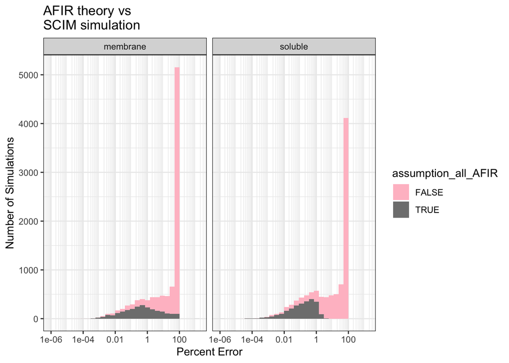

```r
data_plot = data

g = ggplot(data_plot, aes(AFIR_SCIM_pcterr*100, fill = assumption_all_AFIR))
g = g + geom_histogram()
g = g + xgx_scale_x_log10()
g = g + facet_wrap(~target)
g = g + scale_fill_manual(values = c(`TRUE`="grey50",`FALSE`="pink"))
g = g + labs(x = "Percent Error",
             y = "Number of Simulations")
g = g + ggtitle("AFIR theory vs\nSCIM simulation")
print(g)
```

# Explore agreemnet between SCIM theory and SCIM simulation

List of assumptions. They are similar to the AFIR assumptions, but now we allow for accumulation of Ligand

- SCIM < 30%
- Cavgss >> Ttotss (5x larger)
- Cavgss >> Kss_DT (5x)
- koff_DT > keT (binding faster than elimination)
- koff_TL > 1/30 (not too slow)
- Cavgss >> Kss_DT*Lss/Kss_TL (enough binding)

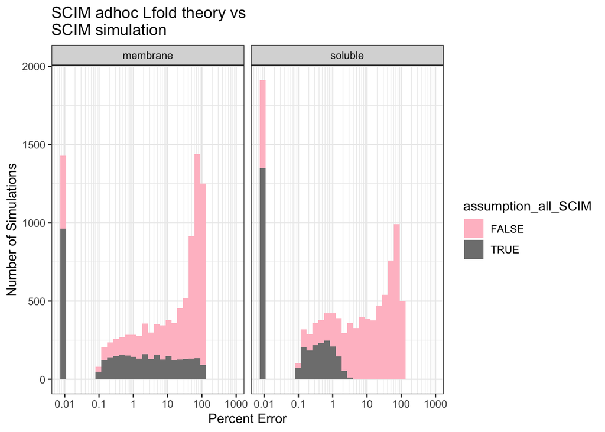

```r
g = ggplot(data_plot, aes(SCIM_SCIM_pcterr*100, fill = assumption_all_SCIM))
g = g + geom_histogram()
g = g + xgx_scale_x_log10()
g = g + facet_wrap(~target)
g = g + scale_fill_manual(values = c(`TRUE`="grey50",`FALSE`="pink"))
g = g + labs(x = "Percent Error",
             y = "Number of Simulations")
g = g + ggtitle("SCIM adhoc Lfold theory vs\nSCIM simulation")
print(g)
```

# Look into large error with assumptions - check tol for ODE

```r
data_focus = data %>%
  filter(assumption_all_SCIM == TRUE) %>%
  arrange(desc(SCIM_SCIM_pcterr)) %>%
  mutate(Dss_TLss_thy_ratio = Dss_thy/TLss_thy,
         Dss_TLss_sim_ratio = Dss_sim/TLss_sim)

data_focus %>%
  select(id,SCIM_SCIM_pcterr,contains("Dss_TLss")) %>%
  slice(1:10) %>%
  kable()
```

| id | SCIM_SCIM_pcterr | Dss_TLss_thy_ratio | Dss_TLss_sim_ratio |
| --- | --- | --- | --- |
| 7651 | 8.7576165 | 1.639892e+13 | -1.193429e+14 |
| 5843 | 0.9997266 | 2.663899e+06 | 1.176815e-01 |
| 5613 | 0.9992940 | 2.811273e+08 | 8.016913e+01 |
| 8297 | 0.9989941 | 3.186301e+05 | 1.611983e-01 |
| 945 | 0.9988974 | 2.052315e+06 | 2.255695e+00 |
| 8857 | 0.9986141 | 1.070603e+07 | 1.468915e+01 |
| 1693 | 0.9983561 | 4.683963e+06 | 9.169246e+00 |
| 5281 | 0.9980033 | 3.768424e+07 | 5.843515e+01 |
| 7850 | 0.9977516 | 5.252464e+04 | 1.600193e-01 |
| 3547 | 0.9976103 | 7.462334e+08 | 2.916145e+03 |

# D is way lower than predicted

### Because Dss < Ccrit, so all the Drug is getting internalized

From the theory:

- Ttotss = 100
- Dss = 600
- keDT = 13
- CL = .27
- V = 3
- …
- linear elimination = Dss*CL = 600*.27 ~ 150
- nonlinear elimination =
- Ccrit = Vm/CL = ksynT*V1/CL = 1375*3/.27 = 15,000

Ok, so Dss is not large enough. We need a check that it’s above Ccrit.

Shoot, I forgot what run illustrated this issue… It’s not 9129. I think it’s a mistake that I plot it below.

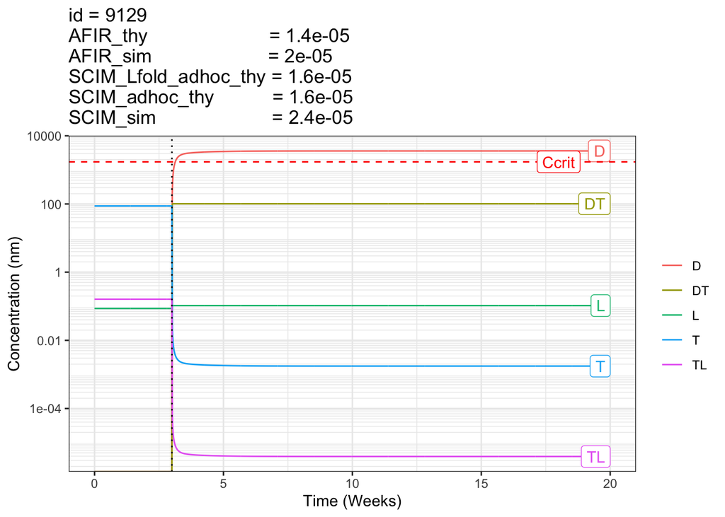

```r
id_plot = 9129
d = data %>% filter(id==id_plot)

out = plot_param(d,model)
```

```r
kable(out$param)
```

| id | CL | T0 | L0 | Kd_DT | Kd_TL | kon_DT | kon_TL | keT | keL | keDT | keTL |
| --- | --- | --- | --- | --- | --- | --- | --- | --- | --- | --- | --- |
| 9129 | 2.4 | 87.48069 | 0.0862016 | 0.0059065 | 41.90475 | 240.7921 | 10.08595 | 15.63643 | 441.9714 | 13.556 | 50.21906 |

```r
kable(out$compare)
```

| type | Dss | T0 | L0 | TL0 | Ttotss | Lss | TLss | AFIR | SCIM |
| --- | --- | --- | --- | --- | --- | --- | --- | --- | --- |
| sim | 3592.701 | 87.48069 | 0.0862016 | 0.1608438 | 101.5019 | 0.1044771 | 3.9e-06 | 2.01e-05 | 2.43e-05 |
| thy | 5312.622 | 87.48069 | 0.0862016 | 0.1608438 | 101.5022 | 0.1044775 | 2.6e-06 | 1.36e-05 | 1.65e-05 |

# This simulation seems to be giving a negative TLss

### This is due to the large difference between Dss and TLss

ODE can’t solve it accurately. But only one patient like this (see above)

```r
id_plot = 7651
d = data %>% filter(id==id_plot)

print(paste("Cavgss: ", d$Cavgss))
```

```
## [1] "Cavgss:  6.19384277825685"
```

```r
print(paste("TLss: ", d$TLss_thy))
```

```
## [1] "TLss:  3.77698237717471e-13"
```

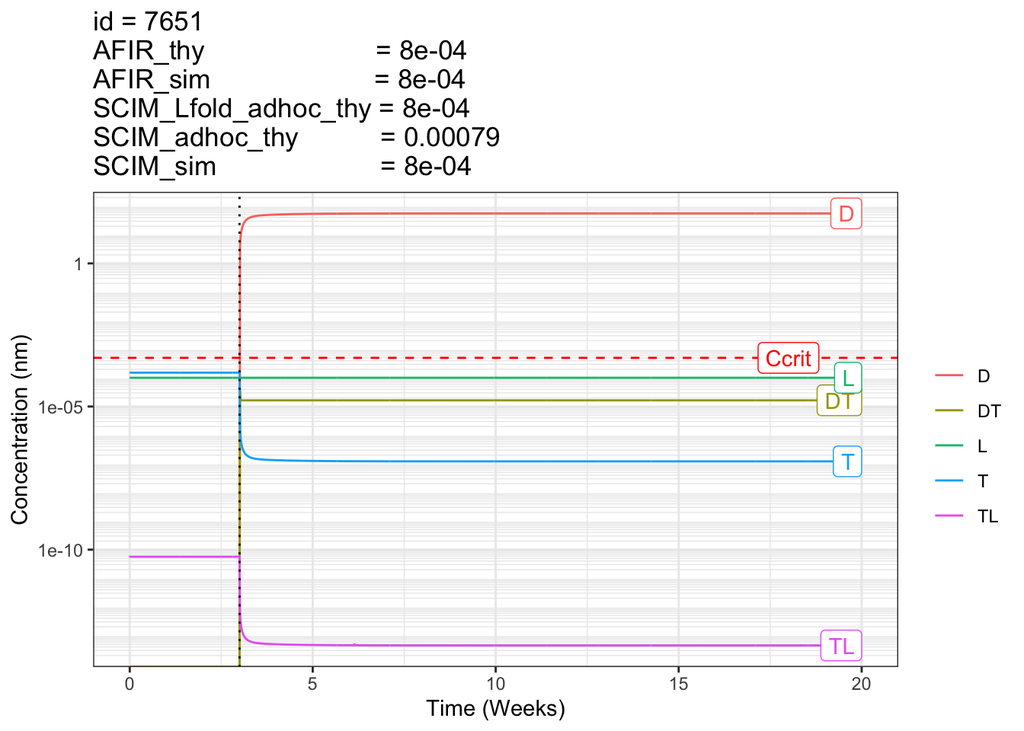

```r
out = plot_param(d,model, plot_flag = FALSE)
print(out$plot)
```

```r
kable(out$param)
```

| id | CL | T0 | L0 | Kd_DT | Kd_TL | kon_DT | kon_TL | keT | keL | keDT | keTL |
| --- | --- | --- | --- | --- | --- | --- | --- | --- | --- | --- | --- |
| 7651 | 2.4 | 0.0001525 | 0.0001012 | 0.0083629 | 272.5591 | 60.49843 | 1440.558 | 2.631383 | 314.5778 | 24.36067 | 231.7575 |

```r
kable(out$compare)
```

| type | Dss | T0 | L0 | TL0 | Ttotss | Lss | TLss | AFIR | SCIM |
| --- | --- | --- | --- | --- | --- | --- | --- | --- | --- |
| sim | 55.74407 | 0.0001525 | 0.0001012 | 0 | 1.66e-05 | 0.0001012 | 0 | 0.0007959 | 0.0007959 |
| thy | 55.74459 | 0.0001525 | 0.0001012 | 0 | 1.65e-05 | 0.0001012 | 0 | 0.0007959 | 0.0007907 |

```r
print(d$SCIM_sim)
```

```
## [1] -0.0009174685
```

# Look at a patient with all assumptions true and large error

### Something strange is going on, with the Dss_sim and Dss_thy

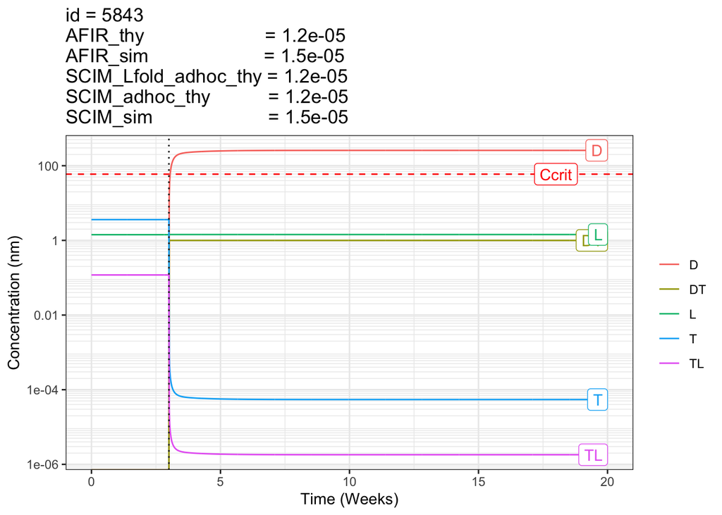

```r
x = data_focus
d = x[2,]

out = plot_param(d,model)
```

```r
kable(out$param)
```

| id | CL | T0 | L0 | Kd_DT | Kd_TL | kon_DT | kon_TL | keT | keL | keDT | keTL |
| --- | --- | --- | --- | --- | --- | --- | --- | --- | --- | --- | --- |
| 5843 | 2.4 | 3.598531 | 1.421341 | 0.0010895 | 38.34659 | 3671.23 | 21.36678 | 9.849642 | 908.1554 | 47.65871 | 101.8217 |

```r
kable(out$compare)
```

| type | Dss | T0 | L0 | TL0 | Ttotss | Lss | TLss | AFIR | SCIM |
| --- | --- | --- | --- | --- | --- | --- | --- | --- | --- |
| sim | 257.9288 | 3.598531 | 1.421341 | 0.1186385 | 0.9972192 | 1.434643 | 1.8e-06 | 1.51e-05 | 1.53e-05 |
| thy | 317.3332 | 3.598531 | 1.421341 | 0.1186385 | 0.9971781 | 1.434643 | 1.5e-06 | 1.23e-05 | 1.24e-05 |

```r
print("original simulation result")
```

```
## [1] "original simulation result"
```

```r
Dss_calc = with(d,dose_nmol/CL/tau)
d %>%
  select(id,Dss_sim, Dss_thy, T0_sim, L0_sim, TL0_sim, Ttotss_sim, Lss_sim, TLss_sim, AFIR_sim, SCIM_sim, SCIM_Lfold_adhoc_thy) %>%
  kable()
```

|  | id | Dss_sim | Dss_thy | T0_sim | L0_sim | TL0_sim | Ttotss_sim | Lss_sim | TLss_sim | AFIR_sim | SCIM_sim | SCIM_Lfold_adhoc_thy |
| --- | --- | --- | --- | --- | --- | --- | --- | --- | --- | --- | --- | --- |
| 2 | 5843 | 0.0056996 | 35.25924 | 3.598531 | 1.421341 | 0.1186385 | 2.101157 | 1.429213 | 0.0484324 | 0.4059871 | 0.4082355 | 0.0001116 |

# Continue looking at patient with all assumptions true and large error

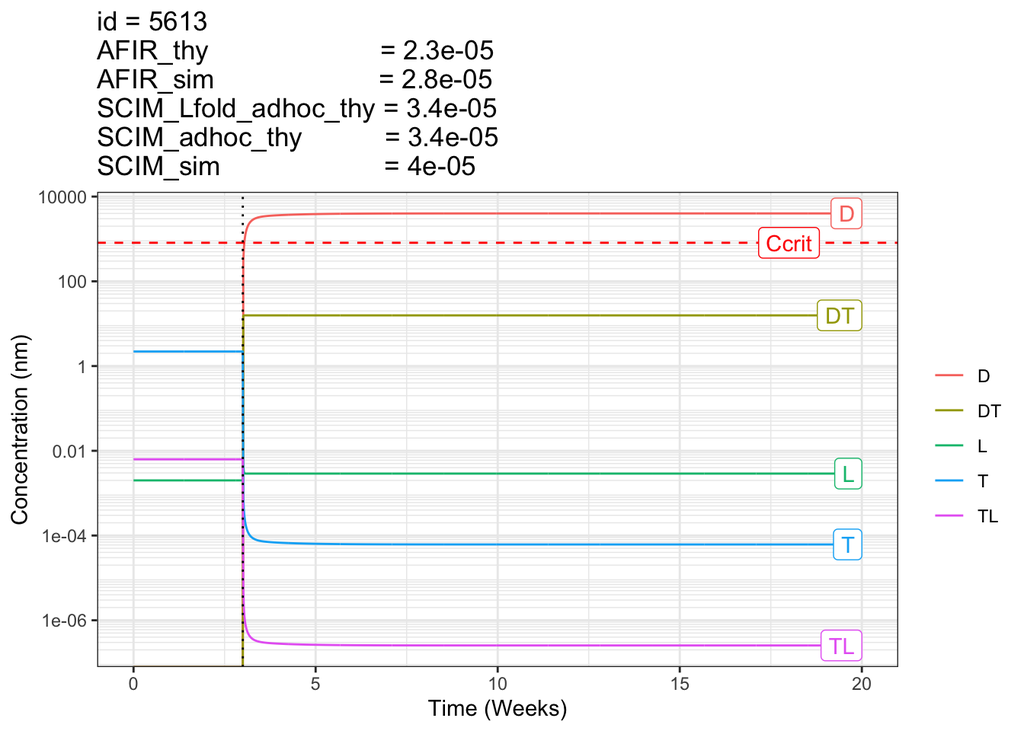

```r
out = plot_param(x[3,],model)
```

```r
kable(out$param)
```

| id | CL | T0 | L0 | Kd_DT | Kd_TL | kon_DT | kon_TL | keT | keL | keDT | keTL |
| --- | --- | --- | --- | --- | --- | --- | --- | --- | --- | --- | --- |
| 5613 | 2.4 | 2.205328 | 0.0020009 | 0.0107195 | 0.6933221 | 8306.887 | 276.7494 | 294.3595 | 14.37925 | 41.328 | 2.041777 |

```r
kable(out$compare)
```

| type | Dss | T0 | L0 | TL0 | Ttotss | Lss | TLss | AFIR | SCIM |
| --- | --- | --- | --- | --- | --- | --- | --- | --- | --- |
| sim | 4003.891 | 2.205328 | 0.0020009 | 0.0062976 | 15.70743 | 0.0028951 | 3e-07 | 2.79e-05 | 4.04e-05 |
| thy | 4815.334 | 2.205328 | 0.0020009 | 0.0062976 | 15.70781 | 0.0028952 | 2e-07 | 2.32e-05 | 3.36e-05 |

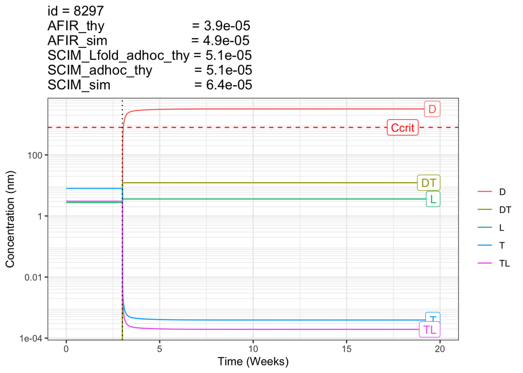

```r
out = plot_param(x[4,],model)
```

```r
kable(out$param)
```

| id | CL | T0 | L0 | Kd_DT | Kd_TL | kon_DT | kon_TL | keT | keL | keDT | keTL |
| --- | --- | --- | --- | --- | --- | --- | --- | --- | --- | --- | --- |
| 8297 | 2.4 | 8.025685 | 2.767264 | 0.0034039 | 7.219092 | 523.844 | 2720.436 | 17.59244 | 593.433 | 51.88839 | 162.4719 |

```r
kable(out$compare)
```

| type | Dss | T0 | L0 | TL0 | Ttotss | Lss | TLss | AFIR | SCIM |
| --- | --- | --- | --- | --- | --- | --- | --- | --- | --- |
| sim | 3210.681 | 8.025685 | 2.767264 | 3.051209 | 12.27479 | 3.602580 | 0.0001939 | 4.88e-05 | 6.35e-05 |
| thy | 4006.792 | 8.025685 | 2.767264 | 3.051209 | 12.27494 | 3.602633 | 0.0001553 | 3.91e-05 | 5.09e-05 |

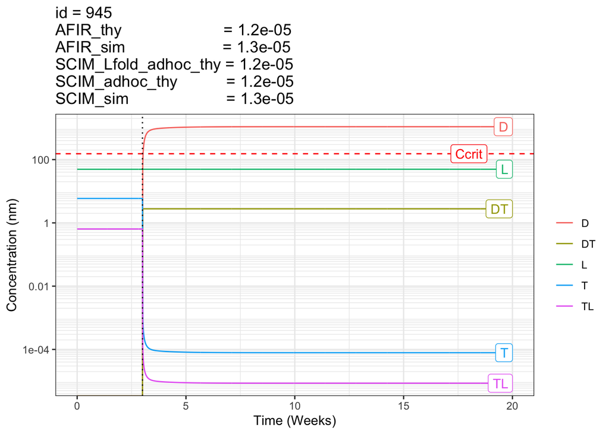

```r
out = plot_param(x[5,],model)
```

```r
kable(out$param)
```

| id | CL | T0 | L0 | Kd_DT | Kd_TL | kon_DT | kon_TL | keT | keL | keDT | keTL |
| --- | --- | --- | --- | --- | --- | --- | --- | --- | --- | --- | --- |
| 945 | 2.4 | 5.919437 | 49.47984 | 0.0120516 | 457.0466 | 2313.107 | 7917.511 | 11.43437 | 624.0278 | 44.1192 | 85.65549 |

```r
kable(out$compare)
```

| type | Dss | T0 | L0 | TL0 | Ttotss | Lss | TLss | AFIR | SCIM |
| --- | --- | --- | --- | --- | --- | --- | --- | --- | --- |
| sim | 1095.173 | 5.919437 | 49.47984 | 0.6408227 | 2.77832 | 49.5678 | 8.6e-06 | 1.33e-05 | 1.34e-05 |
| thy | 1248.390 | 5.919437 | 49.47984 | 0.6408227 | 2.77827 | 49.5678 | 7.5e-06 | 1.17e-05 | 1.17e-05 |